# Introduction

### It is categorized tree with explanation each branch

Categorizer  
Top  
campus - всё, что касается проблем с системоой "Кампус"  
corruption - всё, что касается проблем с коррупцией  
cons - выступающие против коррупции  
pros - выступающие в поддержку коррупции  
danger - всё, что касается безопасности на территории КПИ  
bandit - о проблемах с бандитизмом, преступностью  
drugs - о проблемах с наркотиками, их подкидыванием  
thieves - о проблемах с воровством  
discrimination - о проблеме дискриминации  
gender - о дискриминации по половому признаку  
distance_studying - о проблемах дистанционного обучения  
dormitory - о проблемах общежитий  
administration - проблемы, связанные с администрацией общежитий  
conditions - проблемы, связанные с условиями проживания в общежитиях  
quarantine - проблемы, связанные с введением карантина в общежитиях  
harassment - о проблемах оскроблений и неподобающего поведения преподавателей  
abuse - о вербальных оскорблениях и унижениях  
perversion - о проблемах домагательств, неоднозначных действий сексуального характера  
violence - о проблемах физического насилия в сторону студентов  
lateness - о проблеме опозданий  
profanity - тексты, содержащие хотя бы 1 мат))  
RS - о проблемах РСО  
absense - о проблеме не оглашения РСО студентам, её отсутствии  
inconsistency - о проблеме не соответсвия реальности РСО  
study_conditions - о проблеме условий учебы  
study_load - о проблеме учебной нагрузки на студентов  
study_relevance - о проблеме актуальности учебной программы  
teacher_inadequancy - о проблеме неадекватности преподавателей  
human_qualities - о проблеме неадекватноси на личностной основе  
requirements - о проблеме неадекватности/завышении требований

```python
import pandas as pd
import numpy as np
import re
import matplotlib.pyplot as plot
import os
```

```python
csv_final_reports = []
dir_with_csv = os.curdir + './reports_separate/'
names_of_csv = os.listdir(dir_with_csv)
```

### Create list of file names in directory

```python
print(f"len:\t{len(names_of_csv)}")
names_of_csv = names_of_csv[:-1]
names_of_csv
```

```
len:	32
```

```
['lateness.csv',
 'dormitory.csv',
 'human_qualities.csv',
 'cons.csv',
 'administration.csv',
 'harassment.csv',
 'corruption.csv',
 'bandit.csv',
 'quarantine.csv',
 'RS.csv',
 'campus.csv',
 'abuse.csv',
 'profanity.csv',
 'drugs.csv',
 'thieves.csv',
 'requirements.csv',
 'gender.csv',
 'study_load.csv',
 'discrimination.csv',
 '29_05.csv',
 'absense.csv',
 'danger.csv',
 'violence.csv',
 'pros.csv',
 'distance_studying.csv',
 'study_conditions.csv',
 'conditions.csv',
 'teacher_inadequancy.csv',
 'perversion.csv',
 'study_relevance.csv',
 'inconsistency.csv']
```

Create **csv_final_report** like concatination all csv format files

```python
for i,file_name in enumerate(names_of_csv[:-1]):
    file_name = dir_with_csv + file_name
    print(f"i; {i}\t file_name:\t{file_name}")
    if i == 0:
        csv_final_report = pd.read_csv(file_name)
        print(f"len_of_current_report:\t{len(csv_final_report)}")
        print(f"len_of_final_report:\t{len(csv_final_report)}")
        continue

    current_csv = pd.read_csv(file_name)
    csv_final_report = csv_final_report.append(current_csv, ignore_index=True)

    print(f"len_of_current_report:\t{len(current_csv)}")
    print(f"len_of_final_report:\t{len(csv_final_report)}")

csv_final_report.head
```

```
i; 0	 file_name:	../reports_separate/lateness.csv
len_of_current_report:	23
len_of_final_report:	23
i; 1	 file_name:	../reports_separate/dormitory.csv
len_of_current_report:	492
len_of_final_report:	515
i; 2	 file_name:	../reports_separate/human_qualities.csv
len_of_current_report:	53
len_of_final_report:	568
i; 3	 file_name:	../reports_separate/cons.csv
len_of_current_report:	17
len_of_final_report:	585
i; 4	 file_name:	../reports_separate/administration.csv
len_of_current_report:	56
len_of_final_report:	641
i; 5	 file_name:	../reports_separate/harassment.csv
len_of_current_report:	53
len_of_final_report:	694
i; 6	 file_name:	../reports_separate/corruption.csv
len_of_current_report:	135
len_of_final_report:	829
i; 7	 file_name:	../reports_separate/bandit.csv
len_of_current_report:	11
len_of_final_report:	840
i; 8	 file_name:	../reports_separate/quarantine.csv
len_of_current_report:	22
len_of_final_report:	862
i; 9	 file_name:	../reports_separate/RS.csv
len_of_current_report:	70
len_of_final_report:	932
i; 10	 file_name:	../reports_separate/campus.csv
len_of_current_report:	38
len_of_final_report:	970
i; 11	 file_name:	../reports_separate/abuse.csv
len_of_current_report:	29
len_of_final_report:	999
i; 12	 file_name:	../reports_separate/profanity.csv
len_of_current_report:	101
len_of_final_report:	1100
i; 13	 file_name:	../reports_separate/drugs.csv
```

[output cut: 35 more lines]

```
i; 25	 file_name:	../reports_separate/study_conditions.csv
len_of_current_report:	79
len_of_final_report:	1998
i; 26	 file_name:	../reports_separate/conditions.csv
len_of_current_report:	200
len_of_final_report:	2198
i; 27	 file_name:	../reports_separate/teacher_inadequancy.csv
len_of_current_report:	48
len_of_final_report:	2246
i; 28	 file_name:	../reports_separate/perversion.csv
len_of_current_report:	38
len_of_final_report:	2284
i; 29	 file_name:	../reports_separate/study_relevance.csv
len_of_current_report:	28
len_of_final_report:	2312
```

```
<bound method NDFrame.head of       file_code  pass  is_fail_doc        category_name  relevancy  \
0          1022     1            0         Top/lateness        1.0
1          1237     1            0         Top/lateness        1.0
2           128     1            0         Top/lateness        1.0
3          1533     1            0         Top/lateness        1.0
4          1642     1            0         Top/lateness        1.0
...         ...   ...          ...                  ...        ...
2307       4345     1            0  Top/study_relevance        1.0
2308        553     1            0  Top/study_relevance        1.0
2309         58     1            0  Top/study_relevance        1.0
2310        807     1            0  Top/study_relevance        1.0
2311         93     1            0  Top/study_relevance        1.0

      above_rel_cutoff                  date
0                    1  30May2014 17:14:39.0
1                    1  30May2014 17:14:39.0
2                    1  30May2014 17:14:39.0
3                    1  30May2014 17:14:39.0
4                    1  30May2014 17:14:39.0
...                ...                   ...
2307                 1  30May2014 17:18:14.0
2308                 1  30May2014 17:18:14.0
2309                 1  30May2014 17:18:14.0
2310                 1  30May2014 17:18:14.0
2311                 1  30May2014 17:18:14.0

[2312 rows x 7 columns]>
```

```python
file_name_source = 'Test_shorts (version 1+period) (2).xlsx'
excel_sourse = pd.read_excel(file_name_source, index_col=0)
```

```python
csv_final_report.head
```

```
<bound method NDFrame.head of       file_code  pass  is_fail_doc        category_name  relevancy  \
0          1022     1            0         Top/lateness        1.0
1          1237     1            0         Top/lateness        1.0
2           128     1            0         Top/lateness        1.0
3          1533     1            0         Top/lateness        1.0
4          1642     1            0         Top/lateness        1.0
...         ...   ...          ...                  ...        ...
2307       4345     1            0  Top/study_relevance        1.0
2308        553     1            0  Top/study_relevance        1.0
2309         58     1            0  Top/study_relevance        1.0
2310        807     1            0  Top/study_relevance        1.0
2311         93     1            0  Top/study_relevance        1.0

      above_rel_cutoff                  date
0                    1  30May2014 17:14:39.0
1                    1  30May2014 17:14:39.0
2                    1  30May2014 17:14:39.0
3                    1  30May2014 17:14:39.0
4                    1  30May2014 17:14:39.0
...                ...                   ...
2307                 1  30May2014 17:18:14.0
2308                 1  30May2014 17:18:14.0
2309                 1  30May2014 17:18:14.0
2310                 1  30May2014 17:18:14.0
2311                 1  30May2014 17:18:14.0

[2312 rows x 7 columns]>
```

```python
excel_sourse.head
```

```
<bound method NDFrame.head of                                                         Text  \
Name file
2          #ИПИ, 5 курс:\n\n"С 1 по 4 курс редактирование...
3          за 20 дней со дня создания влетели в сотню луч...
4          ФИВТ 2 курс ТК \n\nВо втором семестре у нас бы...
5          Хай!\nРешили создать отдельный канал для жалоб...
6          #ТЭФ, 1 курс:\n\n"И еще на счет доп баллов. Пр...
...                                                      ...
4389       У нас преподаватели делают такие задания, что ...
4390       Почему если много студентов пишут тест на "хор...
4391       То есть, получется, что студенты заслуживают п...
4392       У вас или у представителя есть доказательства ...
4393       Михайло Анатолійович - професіонал своєї справ...

                                Date
Name file
2          2018-01-14 08:44:40+00:00
3          2018-01-13 23:22:33+00:00
4          2018-01-13 23:16:09+00:00
5          2018-01-13 21:04:45+00:00
6          2018-01-13 19:36:35+00:00
...                              ...
4389       2020-04-28 04:15:58+00:00
4390       2020-04-27 19:04:54+00:00
4391       2020-04-27 19:04:40+00:00
4392       2020-04-27 18:42:54+00:00
4393       2020-04-27 18:24:06+00:00

[4388 rows x 2 columns]>
```

### Create '*new_csv*' as columbs of ['file_code', 'class', 'date']

```python
name_colums_for_new_csv = ['file_code', 'class', 'date']
new_csv = pd.DataFrame(zip(csv_final_report.file_code, csv_final_report.category_name, csv_final_report.date), columns=name_colums_for_new_csv)
```

```python
new_csv.head
```

```
<bound method NDFrame.head of       file_code                class                  date
0          1022         Top/lateness  30May2014 17:14:39.0
1          1237         Top/lateness  30May2014 17:14:39.0
2           128         Top/lateness  30May2014 17:14:39.0
3          1533         Top/lateness  30May2014 17:14:39.0
4          1642         Top/lateness  30May2014 17:14:39.0
...         ...                  ...                   ...
2307       4345  Top/study_relevance  30May2014 17:18:14.0
2308        553  Top/study_relevance  30May2014 17:18:14.0
2309         58  Top/study_relevance  30May2014 17:18:14.0
2310        807  Top/study_relevance  30May2014 17:18:14.0
2311         93  Top/study_relevance  30May2014 17:18:14.0

[2312 rows x 3 columns]>
```

## Function for return all classes from Studio and change a data in colums for real date

```python
def preparation():


    for index in range(len(csv_final_report)):
        count_in_table = int(csv_final_report['file_code'][index])

        find_data = re.findall(r"\d{4}-\d{2}-\d{2}", excel_sourse.loc[count_in_table]['Date'])

        time =  pd.to_datetime(find_data[0], format='%Y-%m-%d', dayfirst=False)
        new_csv.iloc[index,2] = time


    my_classes = list(set(new_csv['class']))
    len_my_classes = len(my_classes)

    return my_classes,len_my_classes
```

```python
my_classes, len_my_classes = preparation()
my_classes
```

```
['Top/dormitory/quarantine',
 'Top/corruption/cons',
 'Top/RS',
 'Top/lateness',
 'Top/study_conditions',
 'Top/profanity',
 'Top/dormitory',
 'Top/danger/thieves',
 'Top/teacher_inadequancy',
 'Top/harassment/perversion',
 'Top/harassment/abuse',
 'Top/teacher_inadequancy/requirements',
 'Top/study_load',
 'Top/danger/drugs',
 'Top/corruption/pros',
 'Top/RS/absense',
 'Top/discrimination',
 'Top/corruption',
 'Top/dormitory/conditions',
 'Top/discrimination/gender',
 'Top/study_relevance',
 'Top/danger/bandit',
 'Top/harassment',
 'Top/danger',
 'Top/RS/inconsistency',
 'Top/dormitory/administration',
 'Top/teacher_inadequancy/human_qualities',
 'Top/distance_studying',
 'Top/harassment/violence',
 'Top/campus']
```

### Delete dublicates in DateFrame

```python
print(f"old_len:\t{len(new_csv)}")
new_csv.drop_duplicates(inplace=True)
print(f"new_len:\t{len(new_csv)}")
new_csv
```

```
old_len:	2312
new_len:	1768
```

## Function return DateFrame objects

### First parametr

**all_source_for_bars** Table where colums are name of classes? only first colum are counts of period, every cell consist of procent of files which passed in current class

### Second parametr

**counts_dates** first colum consist of counts of period, second colum consist of a beginning date period in each period, third colum consist of a ending date period in each period.

```python
def create_result_table(name_colums_for_new_csv, my_classes, days_period, first_day, last_day):

    all_source_for_bars = pd.DataFrame(columns=my_classes)
    dates_period = pd.DataFrame(columns=my_classes)

    last_day = pd.to_datetime(last_day,format='%d/%m/%Y')
    start_period = pd.to_datetime(first_day,format='%d/%m/%Y')
    period_time = pd.Timedelta(days=days_period)
    bool_parametr = True

    counts_dates = pd.DataFrame(columns=['start_period','end_period'])

    while bool_parametr:
        end_period = start_period + period_time

        if end_period >= last_day:
            bool_parametr = False
            end_period = last_day
            break

        counts_dateFrame = pd.DataFrame(columns=name_colums_for_new_csv)

        counts_list = np.array([])
        counts_dates_array = np.array([start_period, end_period])

        counts_dates_temp = pd.DataFrame([counts_dates_array],columns=['start_period','end_period'])
        counts_dates = counts_dates.append(counts_dates_temp, ignore_index=True)

        for index,name_class in enumerate(my_classes):
            counts_dateFrame = new_csv[(new_csv['class'] == name_class) & (start_period <= new_csv['date']) & (new_csv['date'] <= end_period)]

            count = len(counts_dateFrame)

            counts_list = np.append(counts_list, count)

        all_summ = np.sum(counts_list)
        if all_summ > 0:
            counts_list = (counts_list / all_summ ) * 100

        temp_count_table = pd.DataFrame([counts_list],columns=my_classes)
        all_source_for_bars = all_source_for_bars.append(temp_count_table, ignore_index=True)

        start_period = end_period + pd.Timedelta(days=1)

    return all_source_for_bars, counts_dates
```

Enter in **days_period** days period what you want

Enter in **first_day** begining day

Enter in **last_day** last day

```python
days_period = 30
first_day = '10/01/2018'
last_day = '20/05/2020'
res_without_dates, dates = create_result_table(name_colums_for_new_csv, my_classes, days_period, first_day, last_day)
```

```python
dates.head
```

```
<bound method NDFrame.head of    start_period end_period
0    2018-01-10 2018-02-09
1    2018-02-10 2018-03-12
2    2018-03-13 2018-04-12
3    2018-04-13 2018-05-13
4    2018-05-14 2018-06-13
5    2018-06-14 2018-07-14
6    2018-07-15 2018-08-14
7    2018-08-15 2018-09-14
8    2018-09-15 2018-10-15
9    2018-10-16 2018-11-15
10   2018-11-16 2018-12-16
11   2018-12-17 2019-01-16
12   2019-01-17 2019-02-16
13   2019-02-17 2019-03-19
14   2019-03-20 2019-04-19
15   2019-04-20 2019-05-20
16   2019-05-21 2019-06-20
17   2019-06-21 2019-07-21
18   2019-07-22 2019-08-21
19   2019-08-22 2019-09-21
20   2019-09-22 2019-10-22
21   2019-10-23 2019-11-22
22   2019-11-23 2019-12-23
23   2019-12-24 2020-01-23
24   2020-01-24 2020-02-23
25   2020-02-24 2020-03-25
26   2020-03-26 2020-04-25>
```

## Save result in xlsx format files

```python
res_without_dates.to_excel(f'result_{days_period}_d.xlsx')
dates.to_excel(f'date_res_{days_period}_d.xlsx')
```

```python
res_without_dates.head
```

```
<bound method NDFrame.head of     Top/dormitory/quarantine  Top/corruption/cons     Top/RS  Top/lateness  \
0                   0.000000             0.000000  13.207547      7.547170
1                   0.000000             0.000000  12.195122      0.000000
2                   0.000000             0.000000   0.000000      0.000000
3                   0.000000             0.000000   0.000000      0.000000
4                   0.000000             0.000000  18.181818      0.000000
5                   0.000000             0.000000   0.000000      0.000000
6                   0.000000             0.000000  20.000000      0.000000
7                   0.000000             0.000000   0.000000      0.000000
8                   0.000000             2.739726   1.369863      4.109589
9                   0.000000             4.201681   0.840336      2.521008
10                  0.000000             0.000000   1.904762      1.904762
11                  0.000000             0.000000   4.395604      2.197802
12                  0.000000             0.000000   4.580153      0.000000
13                  0.000000             1.000000   0.000000      2.000000
```

[output cut: 189 more lines]

```python
ylim_sub = (0,100)
figsize_sub = (15, 300)
fontsize_sub =12
figsize = (500, 300)
fontsize = 34
```

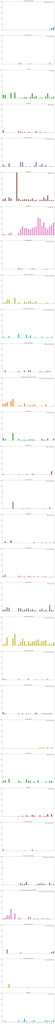

```python
ax = res_without_dates.plot(kind='bar', figsize=figsize_sub, legend=True, fontsize=fontsize_sub, subplots=True, ylim=ylim_sub)
```